# Lab: Causal Inference

# Load packages

Remember, it’s considered a best practice to load all the packages that your file will use up at the top of the file. If you have not yet installed a package, you will need to do so by running `install.packages("package name")` in the R console. For example, to install the `dagitty` package, you would run `install.packages("dagitty")`. However, you typically **do not** want to type the code to install the package here in your Rmd file. That is because you only need to install the package once on a given computer. Not every time you run your R code.

```r
library(dplyr, warn.conflicts = FALSE)
library(dagitty)
```

# Overview

The following lab will cover content that was reviewed in the readings and lectures, including causal models (sufficient component causes and directed acyclic graphs) and a short review of descriptive analysis and regression techniques.

# Task 1

Use R to construct a DAG that depicts a causal relationship between `smoking` and `MI` (myocardial infarctions)? `Smoking` is the cause and `MI` is the effect.

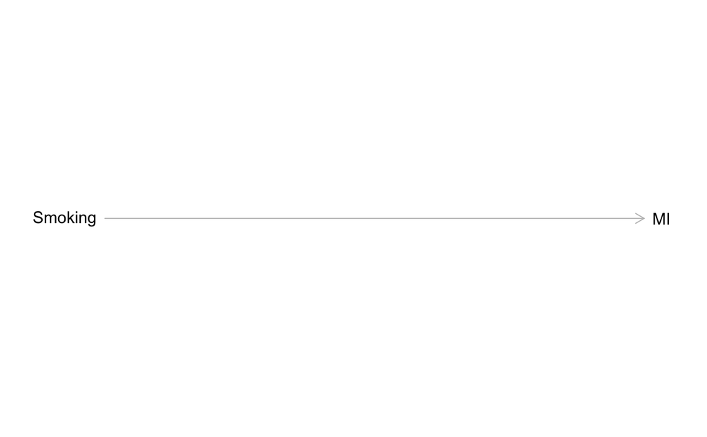

```r
dag_1 <- dagitty('dag {
  Smoking [pos="0,1"]
  MI [pos="1,1"]
  Smoking -> MI
}')
plot(dag_1)
```

# Task 2

Add `cholesterol` to the DAG you created in task 1. In this case, `smoking` is a cause of `cholesterol` and `cholesterol` is a cause of `MI`.

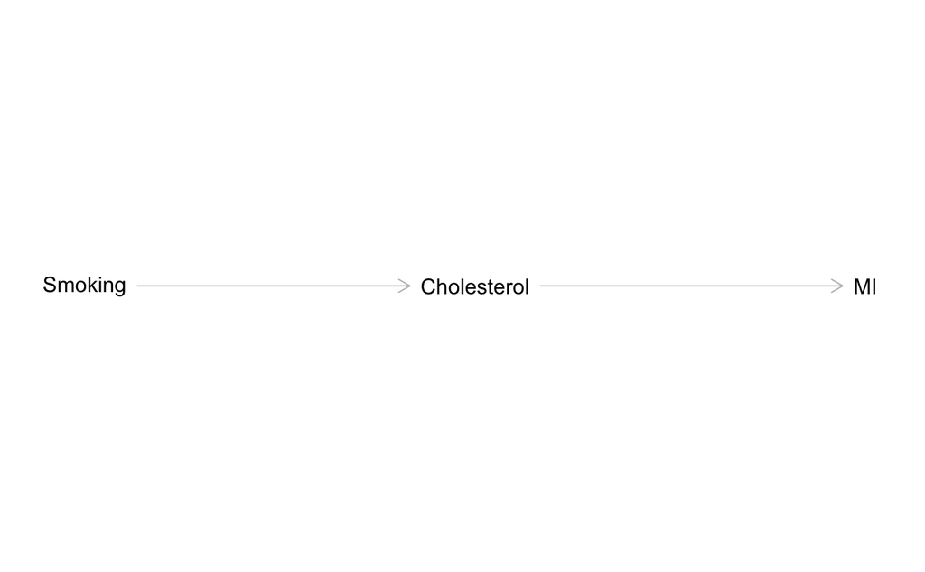

```r
dag_2 <- dagitty('dag {
  Smoking [pos="0,1"]
  Cholesterol [pos="1,1"]
  MI [pos="2,1"]
  Smoking -> Cholesterol -> MI
}')
plot(dag_2)
```

# Question 1

- In the final DAG model, `smoking` is the [exposure, mediator, outcome].
- In the final DAG model, `smoking` is the exposure.

# Question 2

- In the final DAG model, `cholesterol` is the [exposure, mediator, outcome].
- In the final DAG model, `cholesterol` is the mediator.

# Question 3

- In the final DAG model, `MI` is the [exposure, mediator, outcome].
- In the final DAG model, `MI` is the outcome.

# Introduction to the Framingham Heart Study

The Framingham Heart Study is a long term prospective study of the etiology of cardiovascular disease among a population of free living subjects in the community of Framingham, Massachusetts. The Framingham Heart Study was a landmark study in epidemiology in that it was the first prospective study of cardiovascular disease and identified the concept of risk factors and their joint effects. The study began in 1948 and 5,209 subjects were initially enrolled in the study. Note that the following dataset is a teaching dataset and not suitable for publication purposes.

# Task 3

Click the following links to download the * [Framingham heart study dataset](https://www.dropbox.com/s/hulfk3zn37omz96/framingham.csv?dl=0) * [Codebook](https://www.dropbox.com/s/vdossf33acanvhb/Framingham%20Codebook.pdf?dl=0)

# Task 4

Load the following packages in R: `readr`, `dplyr`, `broom`, `ggplot2`, `meantables`, and `freqtables`.

```r
library(readr)
library(dplyr, warn.conflicts = FALSE)
library(broom)
library(ggplot2)
library(meantables)
library(freqtables)
```

# Task 5

Import the Framingham heart study dataset into R and as a data frame named fram.

```r
fram <- read_csv("framingham.csv")
```

# Task 6

View the structure of the data frame.

```r
str(fram)
```

The remaining tasks and questions will help us answer the following research question:

What is the relationship between the exposure systolic blood pressure (“sysbp”) and the outcome heart rate (“heartrte”)?

# Question 4

What is the mean and standard deviation of systolic blood pressure? Round to the nearest 10th decimal.

```r
mean(fram$sysbp, na.rm=TRUE)
sd(fram$sysbp, na.rm=TRUE)
```

# Question 5

What is the mean and standard deviation of heart rate? Round to the nearest 10th decimal. Hint: there are missing values labeled as NA within this column.

```r
mean(fram$heartrte, na.rm=TRUE)
sd(fram$heartrte, na.rm=TRUE)
```

# Question 6

- Which type of regression model would you use to answer this research question?
- Linear because the outcome measure is continuous.

# Task 7

Fit the appropriate regression model to answer the research question.

```r
glm(
  heartrte ~ sysbp,
  family = gaussian(link = "identity"),
  data = fram
)
```

[output not shown]

# Question 7

Fill in the blanks to interpret the result rounding to the nearest 10th decimal place.

- For each unit [drop down: increase/decrease] in systolic blood pressure, there is an average [drop down: increase/decrease] of [0.1] beats for heart rate.
- For each unit increase in systolic blood pressure, there is an average increase of 0.1 beats for heart rate.

# Task 8

Create a scatterplot with the slope to depict the relationship of systolic blood pressure and heart rate.

```r
ggplot(fram, aes(x = sysbp, y = heartrte)) +
  geom_point() +
  geom_smooth(method = 'lm', se = FALSE) +
  geom_abline(intercept = 62.77, slope = 0.098)
```

[output not shown]

# Question 8